# smokingMouse study

Instructor: Daianna

As part of your training, we’ll guide you through an analysis with real bulk RNA-seq data. The dataset that we’ll be using is a `RangedSummarizedExperiment` coming from the `smokingMouse` (Gonzalez-Padilla and Collado-Torres, 2023) package, but in this chapter we’ll explain you the study design and the experimental stages that preceded the data generation.

The smoking mouse study is a project currently being developed at the [Lieber Institute for Brain Development](https://www.libd.org) by Daianna Gonzalez-Padilla and Leonardo Collado-Torres.

## Introduction

Nowadays, maternal smoking during pregnancy (MSDP) is one of the major health concerns worldwide not only because of the effects on the smoker but because the health of the offspring could be dramatically affected by smoking exposure, particularly their cognitive and behavioral traits. But are those effects caused by cigarette smoke only? Or are those alterations given by a specific component of cigarettes such as nicotine? The latter is a very relevant question because most of the studies have focused on analyzing smoking effects, ignoring the role of nicotine, an active component of the cigarettes. Understanding which effects are specifically dictated by nicotine prenatal exposure will enable more directed studies of this drug on the developing brain, once affected genes have been identified and experimentally proven.

## Overview

This study consisted of a series of bulk RNA-sequencing experiments performed on brain samples from adult mice and pups and on blood samples from adults. Adult mice were either exposed to cigarette smoke (what we call smoking experiment and smoking mice) or controls of the smoking experiment, or they were administered nicotine (nicotine experiment and nicotine mice) or controls of the nicotine experiment, and they were either pregnant or not. Smoking, nicotine and control pups are pups that were born to smoking, nicotine and control pregnant mice, respectively. This experimental design allowed us to contrast the altered features in both conditions and to compare the effects in different mouse ages, sexes, tissues and pregnancy states.

The original datasets contain gene, transcript, exon, and exon-exon junction expression levels across 208 samples, but in this course we’ll only use gene data in nicotine samples to simplify the analyses.

## Goals

This project actually aimed to answer 4 questions, all related to smoking and nicotine effects in mouse.

### Main objective

The main goal was to identify and differentiate the effects of prenatal nicotine and smoking exposures on gene, transcript, exon and junction expression of developing brain of pups. Basically, to perform a differential expression analysis on mouse data to find significant feature expression changes.

### Secondary objectives

- To evaluate the affected genes by each substance on adult brain in order to compare pup and adult results.
- To examine the effects of smoking on adult blood and brain to search for overlapping biomarkers in both tissues (Can blood analyses capture environmental effects on brain?)
- To compare mouse differentially expressed genes (DEGs) with results from previous studies in human (Semick, S.A. et al. (2018) and Toikumo, S. et al. (2023)).

Check [here](https://github.com/LieberInstitute/smokingMouse_Indirects/tree/main/code) for the code of the original and complete analyses done.

## Study design

As presented in **Figure 1A)**, 36 pregnant dams and 35 non-pregnant female adult mice were either administered nicotine by intraperitoneal injection (IP; n=12), exposed to cigarette smoke in smoking chambers (n=24), or controls (n=35; 11 nicotine controls and 24 smoking controls). A total of 137 pups were born to pregnant dams: 19 were born to mice that were administered nicotine, 46 to mice exposed to cigarette smoke and the remaining 72 to control mice (23 to nicotine controls and 49 to smoking controls). Samples from frontal cortices of P0 pups and adults were obtained, as well as blood samples from smoking-exposed and smoking control adults. Then, as shown in **B)** RNA was extracted from all those samples and RNA-seq libraries were prepared and sequenced to obtain expression counts for genes, exons, transcripts, and exon-exon junctions.

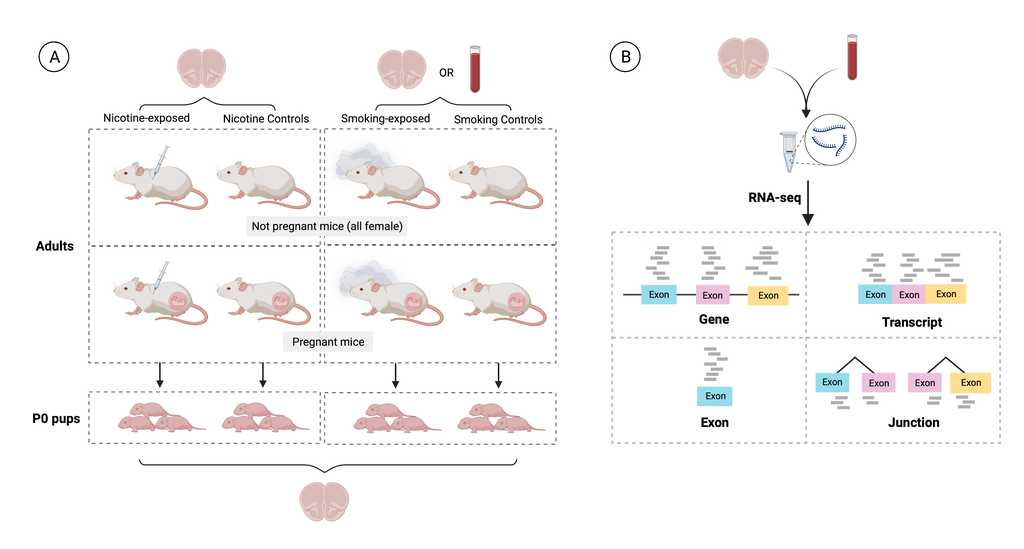

**Figure 1**: **Experimental design of the study**.

## Download data

The whole datasets of this project can be downloaded from the `smokingMouse` (Gonzalez-Padilla and Collado-Torres, 2023) package. Visit [here](http://research.libd.org/smokingMouse/) for more details. For illustrative purposes, we’ll use nicotine data at the gene level which reside in a `RangedSummarizedExperiment` (RSE) object called `rse_gene`.

```r
## Load the container package for this type of data
library("SummarizedExperiment")
## Download data

library('ExperimentHub')
eh <- ExperimentHub::ExperimentHub()
myfiles <- query(eh, "smokingMouse")

## Download the mouse gene data
rse_gene <- myfiles[['EH8313']]
```

```
#> see ?smokingMouse and browseVignettes('smokingMouse') for documentation
#> loading from cache
```

```r
## This is a RangedSummarizedExperiment object
rse_gene
```

```
#> class: RangedSummarizedExperiment
#> dim: 55401 208
#> metadata(1): Obtained_from
#> assays(2): counts logcounts
#> rownames(55401): ENSMUSG00000102693.1 ENSMUSG00000064842.1 ...
#>   ENSMUSG00000064371.1 ENSMUSG00000064372.1
#> rowData names(13): Length gencodeID ... DE_in_pup_brain_nicotine
#>   DE_in_pup_brain_smoking
#> colnames: NULL
#> colData names(71): SAMPLE_ID FQCbasicStats ...
#>   retained_after_QC_sample_filtering
#>   retained_after_manual_sample_filtering
## Check sample info
```

```r
colData(rse_gene)[1:5, 1:5]
```

```
#> DataFrame with 5 rows and 5 columns
#>     SAMPLE_ID FQCbasicStats perBaseQual perTileQual  perSeqQual
#>   <character>   <character> <character> <character> <character>
#> 1 Sample_2914          PASS        PASS        PASS        PASS
#> 2 Sample_4042          PASS        PASS        PASS        PASS
#> 3 Sample_4043          PASS        PASS        PASS        PASS
#> 4 Sample_4044          PASS        PASS        PASS        PASS
#> 5 Sample_4045          PASS        PASS        PASS        PASS
## Check gene info
```

```r
rowData(rse_gene)[1:5, 1:5]
```

```
#> DataFrame with 5 rows and 5 columns
#>                         Length            gencodeID          ensemblID
#>                      <integer>          <character>        <character>
#> ENSMUSG00000102693.1      1070 ENSMUSG00000102693.1 ENSMUSG00000102693
#> ENSMUSG00000064842.1       110 ENSMUSG00000064842.1 ENSMUSG00000064842
#> ENSMUSG00000051951.5      6094 ENSMUSG00000051951.5 ENSMUSG00000051951
#> ENSMUSG00000102851.1       480 ENSMUSG00000102851.1 ENSMUSG00000102851
#> ENSMUSG00000103377.1      2819 ENSMUSG00000103377.1 ENSMUSG00000103377
#>                                 gene_type    EntrezID
#>                               <character> <character>
#> ENSMUSG00000102693.1                  TEC       71042
#> ENSMUSG00000064842.1                snRNA          NA
#> ENSMUSG00000051951.5       protein_coding      497097
#> ENSMUSG00000102851.1 processed_pseudogene   100418032
#> ENSMUSG00000103377.1                  TEC          NA
## Access the original counts
```

```r
original_counts <- assays(rse_gene)$counts
## Access the log normalized counts
logcounts <- assays(rse_gene)$logcounts

## Nicotine data
rse_gene_nic <- rse_gene[, which(rse_gene$Expt == "Nicotine")]
```

## Data overview

### Assays

The dataset `rse_gene` contains the following assays:

- `counts`: original read counts of the 55,401 mouse genes across 208 samples (inlcuding the 65 nicotine samples of interest).
- `logcounts`: normalized and scaled counts ($log_2(CPM + 0.5)$) of the same genes across the same samples; normalization was carried out applying TMM method with `cpm(calcNormFactors())` of *edgeR*.

```r
## Explore main assay (of raw counts)
assay(rse_gene)[1:3, 1:3] ## counts for first 3 genes and 3 samples
```

```
#>                      [,1] [,2] [,3]
#> ENSMUSG00000102693.1    0    0    0
#> ENSMUSG00000064842.1    0    0    0
#> ENSMUSG00000051951.5  811  710  812
## Access the same raw data with assays()
```

```r
assays(rse_gene)$counts[1:3, 1:3]
```

```
#>                      [,1] [,2] [,3]
#> ENSMUSG00000102693.1    0    0    0
#> ENSMUSG00000064842.1    0    0    0
#> ENSMUSG00000051951.5  811  710  812
## Access lognorm counts
```

```r
assays(rse_gene)$logcounts[1:3, 1:3]
```

```
#>                           [,1]      [,2]      [,3]
#> ENSMUSG00000102693.1 -5.985331 -5.985331 -5.985331
#> ENSMUSG00000064842.1 -5.985331 -5.985331 -5.985331
#> ENSMUSG00000051951.5  4.509114  4.865612  4.944597
```

### Sample data

The same RSE contains the sample information in `colData(RSE)`:

- SAMPLE_ID : is the name of the sample.
- ERCCsumLogErr : a summary statistic quantifying overall difference of expected and actual ERCC concentrations for one sample. For more about *ERCC* check their product page at https://www.thermofisher.com/order/catalog/product/4456740.
- overallMapRate : the decimal fraction of reads which successfully mapped to the reference genome (i.e. *numMapped* / *numReads*).
- mitoMapped : the number of reads which successfully mapped to the mitochondrial chromosome.
- totalMapped : the number of reads which successfully mapped to the canonical sequences in the reference genome (excluding mitochondrial chromosomes).
- mitoRate : the decimal fraction of reads which mapped to the mitochondrial chromosome, of those which map at all (i.e. *mitoMapped* / (*totalMapped* + *mitoMapped*))
- totalAssignedGene : the decimal fraction of reads assigned unambiguously to a gene (including mitochondrial genes), with `featureCounts` (Liao et al. 2014), of those in total.
- rRNA_rate : the decimal fraction of reads assigned to a gene whose type is ‘rRNA’, of those assigned to any gene.
- Tissue : tissue (mouse brain or blood) from which the sample comes.
- Age : if the sample comes from an adult or a pup mouse.
- Sex : if the sample comes from a female (F) or male (M) mouse.
- Expt : the experiment (nicotine or smoking exposure) to which the sample mouse was subjected; it could be an exposed or a control mouse of that experiment.
- Group : if the sample belongs to a nicotine/smoking-exposed mouse (Expt) or a nicotine/smoking control mouse (Ctrl).
- plate : is the plate (1,2 or 3) in which the sample library was prepared.
- Pregnancy : if the sample comes from a pregnant (Yes) or not pregnant (No) mouse.
- medium : is the medium in which the sample was treated: water for brain samples and an elution buffer (EB) for the blood ones.
- flowcell : is the sequencing batch of each sample.
- sum : library size (total sum of counts across all genes for each sample).
- detected : number of non-zero expressed genes in each sample.
- subsets_Mito_sum : total sum of read counts of mt genes in each sample.
- subsets_Mito_detected : total number of mt genes in each sample.
- subsets_Mito_percent : % of mt genes’ counts of the total counts of the sample.
- subsets_Ribo_sum : total sum of read counts of ribosomal genes in each sample.
- subsets_Ribo_detected : total number of ribosomal genes in each sample.
- subsets_Ribo_percent : % of ribosomal genes’ counts of the total counts of the sample.

**Note:** in our case, we’ll use samples from the nicotine experiment only, so all samples come from brain and were treated in water.

```r
## Data for first 3 samples and 5 variables
colData(rse_gene)[1:3, 1:5]
```

```
#> DataFrame with 3 rows and 5 columns
#>     SAMPLE_ID FQCbasicStats perBaseQual perTileQual  perSeqQual
#>   <character>   <character> <character> <character> <character>
#> 1 Sample_2914          PASS        PASS        PASS        PASS
#> 2 Sample_4042          PASS        PASS        PASS        PASS
#> 3 Sample_4043          PASS        PASS        PASS        PASS
```

### Gene Information

Among the information in `rowData(RSE)` the next variables are of interest for the analysis:

- gencodeID : GENCODE ID of each gene.
- ensemblID : gene ID in Ensembl database.
- EntrezID : identifier of each gene in NCBI Entrez database.
- Symbol : official gene symbol for each mouse gene.
- retained_after_feature_filtering : Boolean variable that equals TRUE if the gene passed the gene filtering (with `filterByExpr()` of *edgeR*) based on its expression levels and FALSE if not.
- DE_in_adult_brain_nicotine : Boolean variable that equals TRUE if the feature is differentially expressed (DE) in adult brain samples exposed to nicotine and FALSE if not.
- DE_in_pup_brain_nicotine : Boolean variable that equals TRUE if the feature is differentially expressed (DE) in pup brain samples exposed to nicotine and FALSE if not.

```r
## Data for first 3 genes and 5 variables
rowData(rse_gene)[1:3, 1:5]
```

```
#> DataFrame with 3 rows and 5 columns
#>                         Length            gencodeID          ensemblID
#>                      <integer>          <character>        <character>
#> ENSMUSG00000102693.1      1070 ENSMUSG00000102693.1 ENSMUSG00000102693
#> ENSMUSG00000064842.1       110 ENSMUSG00000064842.1 ENSMUSG00000064842
#> ENSMUSG00000051951.5      6094 ENSMUSG00000051951.5 ENSMUSG00000051951
#>                           gene_type    EntrezID
#>                         <character> <character>
#> ENSMUSG00000102693.1            TEC       71042
#> ENSMUSG00000064842.1          snRNA          NA
#> ENSMUSG00000051951.5 protein_coding      497097
```

📑 **Exercise 1**: How would you access data of a specific sample variable?

For illustrative purposes, we’ll use nicotine data at the gene level only so let’s access that data.

```r
## Original dimensions of the data
dim(rse_gene)
```

```
#> [1] 55401   208
```

```r
rse_gene_nic <- rse_gene[, which(rse_gene$Expt == "Nicotine")]
## New dimensions
dim(rse_gene_nic)
```

```
#> [1] 55401    65
```

📑 **Exercise 2**: How could you check that all samples are from the nicotine experiment?

📑 **Exercise 3**: How many nicotine samples correspond to adults and how many to pups? How many pups were males and how many were females?